# Module 2

2023-11-14

#Loading required packages—-

```r
library(base)

library(tidyverse)
property_assessment<- read.csv("fy2023-property-assessment-data.csv")
```

Reading the required dataset.

```r
library(janitor)
property_assessment<- clean_names(property_assessment)
```

Loading the janitor package to convert names from Upper case to Lower.

#Creating customized dataset as per interest variables—-

```r
updated_property_assessment<-  property_assessment[, c("city", "lu", "lu_desc", "bldg_type", "res_floor", "res_units", "com_units", "rc_units", "gross_area", "living_area", "land_value", "bldg_value", "total_value", "gross_tax", "yr_built", "bed_rms", "full_bth", "hlf_bth", "kitchens", "bdrm_cond", "heat_type", "ac_type", "num_parking", "prop_view")]

str(updated_property_assessment)
```

```
## 'data.frame':    180627 obs. of  24 variables:
##  $ city       : chr  "EAST BOSTON" "EAST BOSTON" "EAST BOSTON" "EAST BOSTON" ...
##  $ lu         : chr  "R3" "R3" "R3" "R3" ...
##  $ lu_desc    : chr  "THREE-FAM DWELLING" "THREE-FAM DWELLING" "THREE-FAM DWELLING" "THREE-FAM DWELLING" ...
##  $ bldg_type  : chr  "RE - Row End" "RM - Row Middle" "RM - Row Middle" "RM - Row Middle" ...
##  $ res_floor  : num  3 3 3 3 3 3 3 3 3 3 ...
##  $ res_units  : int  NA NA NA NA NA NA NA NA NA NA ...
##  $ com_units  : int  NA NA NA NA NA NA NA NA NA NA ...
##  $ rc_units   : int  NA NA NA NA NA NA NA NA NA NA ...
##  $ gross_area : int  3353 3299 3392 3108 3700 6278 6432 6048 4339 4659 ...
##  $ living_area: num  2202 2307 2268 2028 2546 ...
##  $ land_value : int  195700 196500 197100 197700 225700 261200 262000 262700 263200 224400 ...
##  $ bldg_value : int  588500 615300 599200 530200 569100 1027100 993200 876500 613100 802800 ...
##  $ total_value: int  784200 811800 796300 727900 794800 1288300 1255200 1139200 876300 1027200 ...
##  $ gross_tax  : num  8422 8719 8552 7818 8536 ...
##  $ yr_built   : int  1900 1920 1905 1900 1900 1900 1900 1900 1900 1900 ...
##  $ bed_rms    : int  6 3 5 5 6 13 14 11 5 6 ...
##  $ full_bth   : int  3 3 3 3 3 6 5 3 3 3 ...
##  $ hlf_bth    : int  0 0 0 0 0 0 0 0 0 0 ...
##  $ kitchens   : int  3 3 3 3 2 3 3 3 3 3 ...
##  $ bdrm_cond  : chr  "" "" "" "" ...
##  $ heat_type  : chr  "W - Ht Water/Steam" "F - Forced Hot Air" "S - Space Heat" "W - Ht Water/Steam" ...
##  $ ac_type    : chr  "N - None" "C - Central AC" "N - None" "N - None" ...
##  $ num_parking: int  3 0 0 0 0 0 0 0 0 0 ...
##  $ prop_view  : chr  "A - Average" "A - Average" "A - Average" "A - Average" ...
```

#Converting interger values to numeric—-

```r
int_columns <- sapply(updated_property_assessment, is.integer)

updated_property_assessment[, int_columns] <- lapply(updated_property_assessment[, int_columns], as.numeric)

str(updated_property_assessment)
```

```
## 'data.frame':    180627 obs. of  24 variables:
##  $ city       : chr  "EAST BOSTON" "EAST BOSTON" "EAST BOSTON" "EAST BOSTON" ...
##  $ lu         : chr  "R3" "R3" "R3" "R3" ...
##  $ lu_desc    : chr  "THREE-FAM DWELLING" "THREE-FAM DWELLING" "THREE-FAM DWELLING" "THREE-FAM DWELLING" ...
##  $ bldg_type  : chr  "RE - Row End" "RM - Row Middle" "RM - Row Middle" "RM - Row Middle" ...
##  $ res_floor  : num  3 3 3 3 3 3 3 3 3 3 ...
##  $ res_units  : num  NA NA NA NA NA NA NA NA NA NA ...
##  $ com_units  : num  NA NA NA NA NA NA NA NA NA NA ...
##  $ rc_units   : num  NA NA NA NA NA NA NA NA NA NA ...
##  $ gross_area : num  3353 3299 3392 3108 3700 ...
##  $ living_area: num  2202 2307 2268 2028 2546 ...
##  $ land_value : num  195700 196500 197100 197700 225700 ...
##  $ bldg_value : num  588500 615300 599200 530200 569100 ...
##  $ total_value: num  784200 811800 796300 727900 794800 ...
##  $ gross_tax  : num  8422 8719 8552 7818 8536 ...
##  $ yr_built   : num  1900 1920 1905 1900 1900 ...
##  $ bed_rms    : num  6 3 5 5 6 13 14 11 5 6 ...
##  $ full_bth   : num  3 3 3 3 3 6 5 3 3 3 ...
##  $ hlf_bth    : num  0 0 0 0 0 0 0 0 0 0 ...
##  $ kitchens   : num  3 3 3 3 2 3 3 3 3 3 ...
##  $ bdrm_cond  : chr  "" "" "" "" ...
##  $ heat_type  : chr  "W - Ht Water/Steam" "F - Forced Hot Air" "S - Space Heat" "W - Ht Water/Steam" ...
##  $ ac_type    : chr  "N - None" "C - Central AC" "N - None" "N - None" ...
##  $ num_parking: num  3 0 0 0 0 0 0 0 0 0 ...
##  $ prop_view  : chr  "A - Average" "A - Average" "A - Average" "A - Average" ...
```

#Managing outliers—-

```r
clean_num_columns <- function(x) {
  # Remove outliers based on IQR
  q1 <- quantile(x, 0.25, na.rm = TRUE)
  q3 <- quantile(x, 0.75, na.rm = TRUE)
  iqr_value <- IQR(x, na.rm = TRUE)

  lower_bound <- q1 - 1.5 * iqr_value
  upper_bound <- q3 + 1.5 * iqr_value

  x_outliers_removed <- ifelse(x < lower_bound | x > upper_bound, NA, x)

  # Impute missing values with the median
  x_clean_data <- ifelse(is.na(x_outliers_removed), median(x, na.rm = TRUE), x_outliers_removed)

  return(x_clean_data)
}

#Clean all numeric columns in the dataset
updated_property_assessment <- updated_property_assessment %>%
  mutate(across(where(is.numeric), clean_num_columns))

# Remove rows with any NA values after cleaning
updated_property_assessment <- na.omit(updated_property_assessment)

updated_property_assessment <- updated_property_assessment %>%
  mutate(city = ifelse(city == "" | is.na(city), "Unknown", city))
```

#Calculating stats for the whole data—-

```r
overall_data_stats<- data.frame(
  updated_property_assessment %>%
    summarise(
      Data_Frame= "Whole Data",
      Mean_Building_Value = mean(bldg_value),
      Mean_Land_Value = mean(land_value),
      Mean_Gross_Tax = mean(gross_tax),
      Mean_Bed_Rms = mean(bed_rms),
      Mean_num_parking = mean(num_parking)
    ))

print(overall_data_stats)
```

```
##   Data_Frame Mean_Building_Value Mean_Land_Value Mean_Gross_Tax Mean_Bed_Rms
## 1 Whole Data            472968.9        95048.67       6187.053     2.887658
##   Mean_num_parking
## 1         1.093054
```

In the above step, the mean of selected variables are being calculated considering the overall dataset.

Next, samples are being created from the population data and the mean will then be compared for each samples with the population

```r
#Setting the seed for random reproducibility

set.seed(100)
sample_1<- sample_n(updated_property_assessment,10000)

sample_1_summary<- data.frame(
  sample_1%>%
    summarise(
          Data_Frame = "Sample 1",
      Mean_Building_Value = mean(bldg_value),
      Mean_Land_Value = mean(land_value),
      Mean_Gross_Tax = mean(gross_tax),
      Mean_Bed_Rms = mean(bed_rms),
      Mean_num_parking = mean(num_parking)
    ))

print(sample_1_summary)
```

```
##   Data_Frame Mean_Building_Value Mean_Land_Value Mean_Gross_Tax Mean_Bed_Rms
## 1   Sample 1            470705.8        95356.82       6158.048       2.8948
##   Mean_num_parking
## 1           1.0955
```

```r
#Creating sample 2----

set.seed(120)

sample_2<- sample_n(updated_property_assessment,10000)

sample_2_summary<- data.frame(
  sample_2 %>%
    summarise(
      Data_Frame = "Sample 2",
      Mean_Building_Value = mean(bldg_value),
      Mean_Land_Value = mean(land_value),
      Mean_Gross_Tax = mean(gross_tax),
      Mean_Bed_Rms = mean(bed_rms),
      Mean_num_parking = mean(num_parking)
    ))

print(sample_2_summary)
```

```
##   Data_Frame Mean_Building_Value Mean_Land_Value Mean_Gross_Tax Mean_Bed_Rms
## 1   Sample 2              478404        95845.07       6240.269       2.8852
##   Mean_num_parking
## 1           1.0915
```

```r
#Creating sample 3----

set.seed(130)

sample_3<- sample_n(updated_property_assessment,10000)

sample_3_summary<- data.frame(
  sample_3 %>%
    summarise(
      Data_Frame = "Sample 3",
      Mean_Building_Value = mean(bldg_value),
      Mean_Land_Value = mean(land_value),
      Mean_Gross_Tax = mean(gross_tax),
      Mean_Bed_Rms = mean(bed_rms),
      Mean_num_parking = mean(num_parking)
    ))

print(sample_3_summary)
```

```
##   Data_Frame Mean_Building_Value Mean_Land_Value Mean_Gross_Tax Mean_Bed_Rms
## 1   Sample 3            471073.3         94490.6        6149.33       2.8954
##   Mean_num_parking
## 1           1.0914
```

```r
comparison_stats_data<- rbind(
  overall_data_stats,
  sample_1_summary,
  sample_2_summary,
  sample_3_summary)

print(comparison_stats_data)
```

```
##   Data_Frame Mean_Building_Value Mean_Land_Value Mean_Gross_Tax Mean_Bed_Rms
## 1 Whole Data            472968.9        95048.67       6187.053     2.887658
## 2   Sample 1            470705.8        95356.82       6158.048     2.894800
## 3   Sample 2            478404.0        95845.07       6240.269     2.885200
## 4   Sample 3            471073.3        94490.60       6149.330     2.895400
##   Mean_num_parking
## 1         1.093054
## 2         1.095500
## 3         1.091500
## 4         1.091400
```

Due to random sampling process, the mean of the samples are slightly different from the population mean for the variables. This is due to the fundamental prinipal of Central Limit Theorem. Though the mean of samples form a normal distribution and these are very close to the overall mean of the population dataset.

Next, focusing on interested parameters from the population data

```r
lu_stats<- updated_property_assessment %>%
  group_by(lu) %>%
  summarise_if(is.numeric,list(
    Mean= ~ mean(., na.rm=TRUE),
    SD=~ sd(., na.rm=TRUE),
    Min= ~min(., na.rm=TRUE),
    Max= ~max(., na.rm=TRUE),
    N= ~sum(!is.na(.))
  ))

print(lu_stats)
```

```
## # A tibble: 17 × 81
##    lu      res_floor_Mean res_units_Mean com_units_Mean rc_units_Mean
##    <chr>            <dbl>          <dbl>          <dbl>         <dbl>
##  1 A                 2.91           3              1             1
##  2 AH                2              3              1             1
##  3 C                 2              3              1             1
##  4 CC                2              3              1             1
##  5 CD                1.27           3              1             1
##  6 CL                2              3              1             1
##  7 CM                2.95           3.34           1.02          1.00
##  8 CP                2              3              1             1
##  9 E                 2              3              1             1
## 10 EA                2              3              1             1
## 11 I                 2              3              1             1
## 12 R1                1.88           3              1             1
## 13 R2                2.17           3              1             1
## 14 R3                2.85           3              1             1
## 15 R4                3.06           3              1             1
## 16 RC                2              3              1             1
## 17 RL - RL           2              3              1             1
## # ℹ 76 more variables: gross_area_Mean <dbl>, living_area_Mean <dbl>,
## #   land_value_Mean <dbl>, bldg_value_Mean <dbl>, total_value_Mean <dbl>,
## #   gross_tax_Mean <dbl>, yr_built_Mean <dbl>, bed_rms_Mean <dbl>,
## #   full_bth_Mean <dbl>, hlf_bth_Mean <dbl>, kitchens_Mean <dbl>,
## #   num_parking_Mean <dbl>, res_floor_SD <dbl>, res_units_SD <dbl>,
## #   com_units_SD <dbl>, rc_units_SD <dbl>, gross_area_SD <dbl>,
## #   living_area_SD <dbl>, land_value_SD <dbl>, bldg_value_SD <dbl>, …
```

#GROUP by city—-

```r
city_grouped_stats<- updated_property_assessment %>%
  group_by(city) %>%
  summarise_if(is.numeric,list(
    Mean= ~ mean(., na.rm=TRUE),
    SD=~ sd(., na.rm=TRUE),
    Min= ~min(., na.rm=TRUE),
    Max= ~max(., na.rm=TRUE),
    N= ~sum(!is.na(.))
  ))
```

#group by land value—-

```r
Land_value_stats<- updated_property_assessment %>%
  group_by(land_value) %>%
  summarise_if(is.numeric,list(
    Mean= ~ mean(., na.rm=TRUE),
    SD=~ sd(., na.rm=TRUE),
    Min= ~min(., na.rm=TRUE),
    Max= ~max(., na.rm=TRUE),
    N= ~sum(!is.na(.))
  ))


print(Land_value_stats)
```

```
## # A tibble: 8,204 × 76
##    land_value res_floor_Mean res_units_Mean com_units_Mean rc_units_Mean
##         <dbl>          <dbl>          <dbl>          <dbl>         <dbl>
##  1          0           1.64           3.04           1.00          1.00
##  2        100           2              3              1             1
##  3        200           2              3              1             1
##  4        300           2              3              1             1
##  5        400           2              3              1             1
##  6        500           2              3              1             1
##  7        548           2              3              1             1
##  8        600           2              3              1             1
##  9        605           2              3              1             1
## 10        700           2              3              1             1
## # ℹ 8,194 more rows
## # ℹ 71 more variables: gross_area_Mean <dbl>, living_area_Mean <dbl>,
## #   bldg_value_Mean <dbl>, total_value_Mean <dbl>, gross_tax_Mean <dbl>,
## #   yr_built_Mean <dbl>, bed_rms_Mean <dbl>, full_bth_Mean <dbl>,
## #   hlf_bth_Mean <dbl>, kitchens_Mean <dbl>, num_parking_Mean <dbl>,
## #   res_floor_SD <dbl>, res_units_SD <dbl>, com_units_SD <dbl>,
## #   rc_units_SD <dbl>, gross_area_SD <dbl>, living_area_SD <dbl>, …
```

#Using sampling method—-

```r
#Considering total_value as the variable of interest----

total_value_summary <- updated_property_assessment %>%
  summarise(
    Mean_Total_Value = mean(total_value, na.rm = TRUE),
    SD_Total_Value = sd(total_value, na.rm = TRUE),
    Min_Total_Value = min(total_value, na.rm = TRUE),
    Max_Total_Value = max(total_value, na.rm = TRUE)
  )


print(total_value_summary)
```

```
##   Mean_Total_Value SD_Total_Value Min_Total_Value Max_Total_Value
## 1         589470.3       365637.5               0         1715800
```

```r
#Using sampling for total value----

set.seed(50)

sample1_total_value <- sample_n(updated_property_assessment, 10000)

total_value_sample_1 <- data.frame(
  sample1_total_value %>%
    summarise(
      Data_Frame = "Sample 1",
      Mean_Total_value = mean(total_value),
      SD_Total_value = sd(total_value),
      max_total_value = max(total_value),
      min_total_value = min(total_value)))

print(total_value_sample_1)
```

```
##   Data_Frame Mean_Total_value SD_Total_value max_total_value min_total_value
## 1   Sample 1         587860.9       365345.4         1715700               0
```

#Sample 2—-

```r
set.seed(42)

sample2_total_value <- sample_n(updated_property_assessment, 10000)

total_value_sample_2 <- data.frame(
  sample2_total_value %>%
    summarise(
      Data_Frame = "Sample 2",
      Mean_Total_value = mean(total_value),
      SD_Total_value = sd(total_value),
      max_total_value = max(total_value),
      min_total_value = min(total_value)))

print(total_value_sample_2)
```

```
##   Data_Frame Mean_Total_value SD_Total_value max_total_value min_total_value
## 1   Sample 2         588937.6         364124         1713600               0
```

We can observe that the summary statistics value of samples is very much closr to the stats of the overall data.

Part 2:

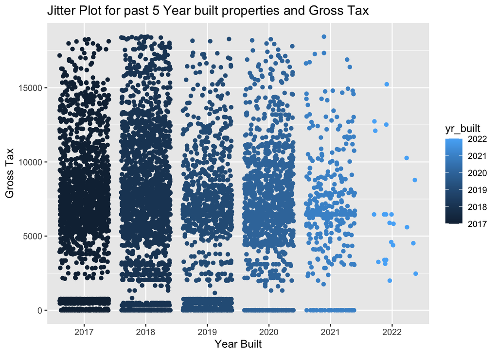

```r
filtered_data <- updated_property_assessment %>%
  filter(yr_built >= (max(yr_built) - 5))

ggplot(filtered_data, aes(x = as.factor(yr_built), y = gross_tax, color = yr_built)) +
  geom_jitter() +
  ggtitle("Jitter Plot for past 5 Year built properties and Gross Tax") +
  xlab("Year Built") +
  ylab("Gross Tax")
```

This jitter plot provides a more detailed view of the distribution of gross_tax for each year of construction within the last 5 years. It helps to identify patterns, concentrations, and potential outliers in the relationship between the construction year and gross tax, with jittering preventing overlap of points and improving visibility.

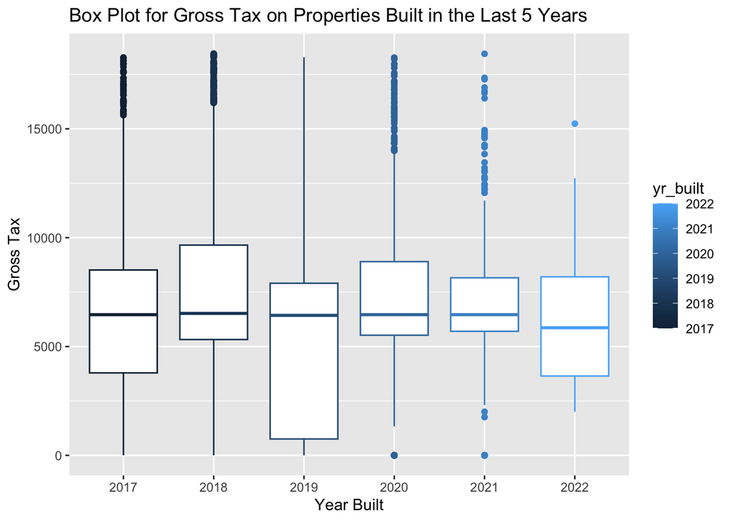

```r
#box plot for gross tax and year built last 5 years----

ggplot(filtered_data, aes(x = as.factor(yr_built), y = gross_tax, color= yr_built)) +
  geom_boxplot() +
  ggtitle("Box Plot for Gross Tax on Properties Built in the Last 5 Years") +
  xlab("Year Built") +
  ylab("Gross Tax")
```

The above box plot explains the relationship between year built of properties and its gross tax. It visually summarizes the distribution of gross_tax for each level of yr_built. It includes a box that represents the interquartile range (IQR) of the data. The horizontal line inside the box represents the median. It provides insights into the central tendency, spread, and potential outliers in the gross_tax variable across different construction years.

#Satterplot for continuous value of gross_tax and total_value—-

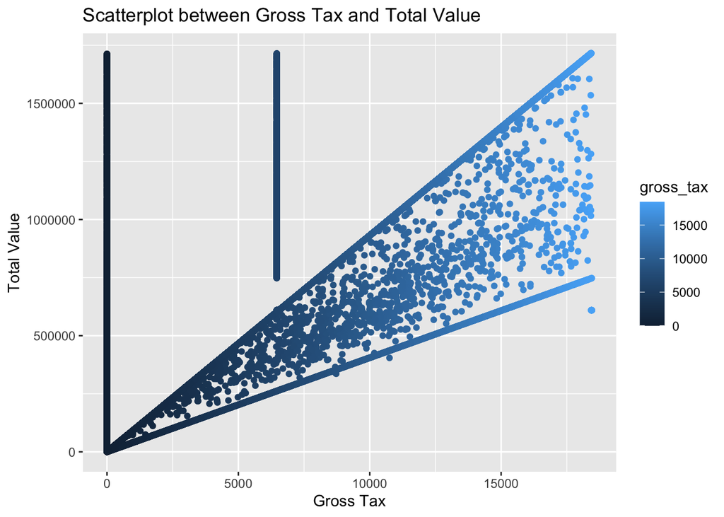

```r
ggplot(updated_property_assessment, aes(x = gross_tax, y = total_value, color = gross_tax)) +
  geom_point() +
  ggtitle("Scatterplot between Gross Tax and Total Value") +
  xlab("Gross Tax") +
  ylab("Total Value")
```

The above scatterplot shows the relationship between total_value and gross tax. The scatterplot visually displays how the values of gross_tax and total_value vary together. Each point represents a property, and its position on the plot indicates its values for both variables. The above scatterplot shows a postive correlation between the values which indicates that with the total value of property, the gross tax also increases.